# Signing the best youngsters for FIFA 22 manager mode.

Mubarak Ganiyu

11/16/2021

```r
library(tidyverse)
library(janitor)
```

## Introduction

When I play FIFA on season mode, I often struggle to sign players due to financial constraints and having no proper idea of which players to sign. The objective of this research is to find those players on FIFA 22 who have a lot of potential for growth while still being cheap to acquire.

```r
df <- read.csv("~/DataBEL/fifa-22/players_22.csv", encoding = "UTF-8") %>%
  clean_names()
```

### Does age have an impact on growth?

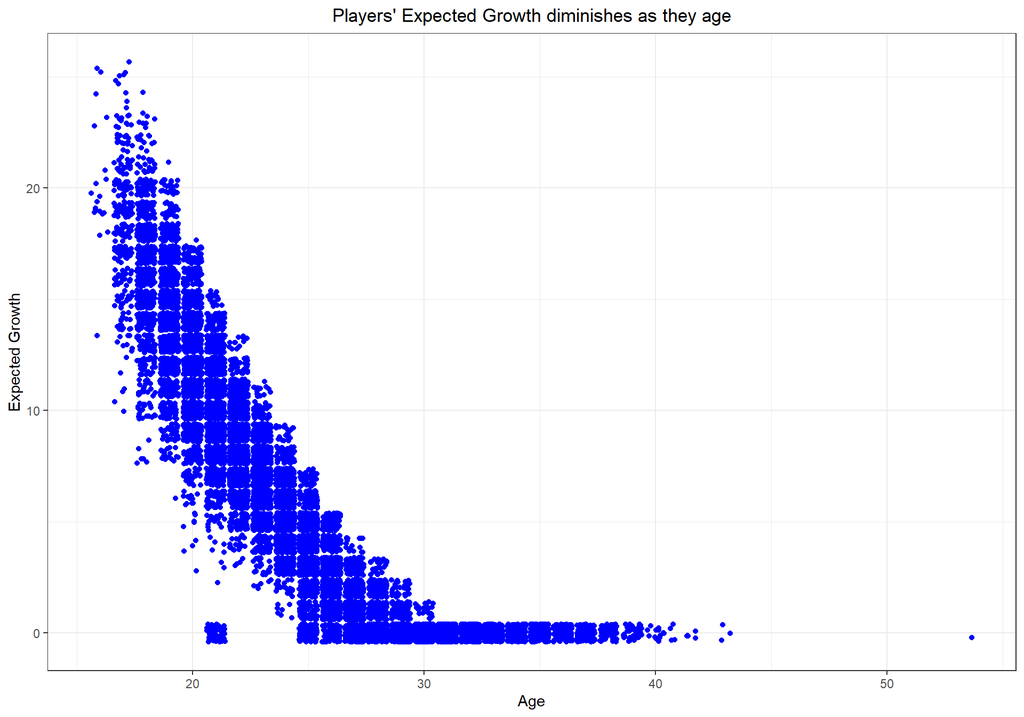

```r
df %>%
  mutate(grow = potential - overall) %>%
  ggplot() +
  geom_jitter(aes(x = age, y = grow), color = "blue") +
  labs(title = "Players' Expected Growth diminishes as they age",
       x = "Age",
       y = "Expected Growth") +
  theme_bw() +
  theme(plot.title = element_text(hjust = 0.5))
```

It can be observed in the chart above that as players age their potential for growth declines.

### Which players have the biggest expected growth in FIFA 22?

#### Top 100 players with the biggest expected growth in FIFA 22

```r
df_growth <- df %>%
  mutate(grow = potential - overall) %>%
  select(short_name, long_name, grow, overall, potential, club_name,
         club_position, age, player_positions, league_name,
         value_eur) %>%
  arrange(desc(grow)) %>%
  head(100)
df_growth[,c("short_name", "grow", "overall","potential", "club_name")] %>%
  arrange(desc(potential))
```

```
##            short_name grow overall potential                   club_name
## 1               Kayky   21      66        87             Manchester City
## 2         D. Scarlett   23      63        86           Tottenham Hotspur
## 3            R. Lavia   23      62        85             Manchester City
## 4            L. Delap   21      64        85             Manchester City
## 5         A. Hackford   25      59        84            Sheffield United
## 6           H. Mejbri   22      62        84           Manchester United
## 7        S. Shoretire   22      62        84           Manchester United
## 8            L. Barry   21      63        84                Ipswich Town
## 9      C. Chukwuemeka   21      63        84                 Aston Villa
## 10    R. van den Berg   24      59        83                  PEC Zwolle
## 11           D. Touré   23      60        83                     Watford
## 12           T. Nakai   22      61        83              Real Madrid CF
## 13           M. Azeez   21      62        83                  Portsmouth
## 14       Fabio Blanco   21      62        83         Eintracht Frankfurt
```

[output cut: 86 more lines]

Due to the fact that these players’ potentials are quite mediocre and not high enough for the players to become world class soccer players, we shall narrow it down to players who have the potential of exceeding 85 or more ratings. Since our objective is to acquire these players for cheap. Then, we shall focus on players who are worth less than 30 million euros. This group of talented cheap players shall be called the Cheap Footy Talent.

### Which players in FIFA 22 can be classified as members of the Footy Talent class?

#### The Footy Talent’s top 100

```r
df_growth <- df %>%
  filter(potential >= 85) %>%
  filter(value_eur <= 30000000) %>%
  mutate(grow = potential - overall) %>%
  select(short_name, long_name, grow, overall, potential, club_name,
         club_position, age, player_positions, league_name,
         value_eur) %>%
  arrange(desc(grow)) %>%
  head(100)
df_growth[,c("short_name", "grow", "overall","potential", "club_name")] %>%
  arrange(desc(grow))
```

```
##              short_name grow overall potential                   club_name
## 1           D. Scarlett   23      63        86           Tottenham Hotspur
## 2              R. Lavia   23      62        85             Manchester City
## 3                 Kayky   21      66        87             Manchester City
## 4              L. Delap   21      64        85             Manchester City
## 5              C. Clark   20      66        86          New York Red Bulls
## 6           L. Stergiou   19      67        86          FC St. Gallen 1879
## 7           F. Carvalho   19      67        86                      Fulham
## 8                  Gavi   19      66        85                FC Barcelona
## 9              B. Šeško   18      68        86        FC Red Bull Salzburg
## 10           A. Vranckx   18      67        85               VfL Wolfsburg
## 11         Talles Magno   18      67        85            New York City FC
## 12            M. Juwara   18      67        85                     Crotone
## 13           N. Rovella   17      70        87                       Genoa
## 14          S. Esposito   17      68        85               FC Basel 1893
```

[output cut: 86 more lines]

Dane Pharell Scarlett is the man to sign if you want to get a player who has a lot of room for growth. Moreover, he is not expensive as he is currently worth about 1,500,000 euros.

### Arranging Footy Talent players in terms of value

```r
df_growth %>%
  select(short_name, age, potential, value_eur,player_positions) %>%
  arrange(value_eur)
```

```
##              short_name age potential value_eur player_positions
## 1              R. Lavia  17        85   1200000              CDM
## 2           D. Scarlett  17        86   1500000               ST
## 3              L. Delap  18        85   1900000               ST
## 4                  Gavi  16        85   2100000               CM
## 5              C. Clark  18        86   2400000          CAM, CM
## 6           L. Stergiou  19        86   2500000               CB
## 7           F. Carvalho  18        86   2600000              CAM
## 8            A. Vranckx  18        85   2600000          CM, CDM
## 9          Talles Magno  19        85   2600000           LM, CF
## 10                Kayky  18        87   2700000               RW
## 11            M. Juwara  19        85   2700000               ST
## 12              L. Netz  18        85   2900000           LB, LM
## 13         K. Kozlowski  17        85   3000000          CAM, CM
## 14             B. Šeško  18        86   3100000               ST
```

[output cut: 86 more lines]

### The leagues with the most footy talent

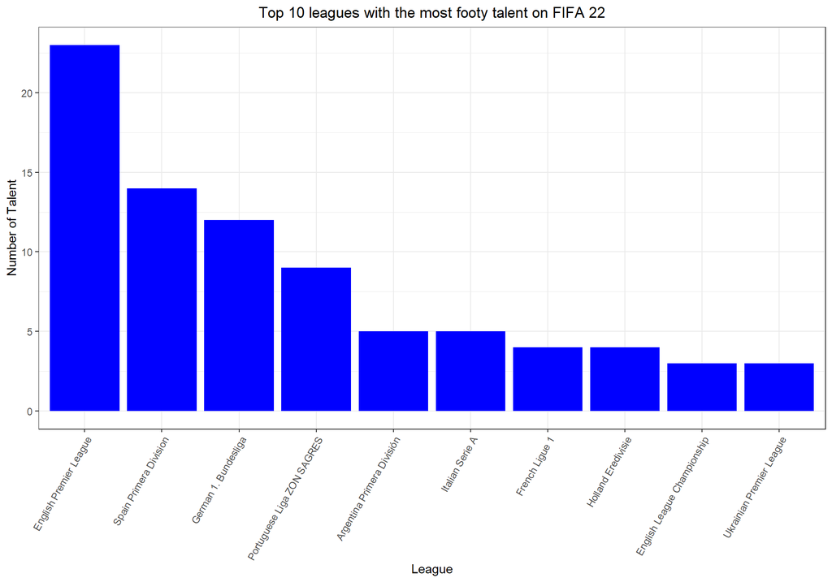

```r
df_growth %>%
  count(league_name) %>%
  arrange(desc(n)) %>%
  head(10) %>%
  ggplot() +
  geom_col(aes(x = reorder(league_name, -n), y = n), fill = "blue") +
  labs(title = "Top 10 leagues with the most footy talent on FIFA 22", x = "League", y = "Number of Talent") +
  theme_bw() +
  theme(plot.title =element_text(hjust = 0.5),
        axis.text.x = element_text(angle = 60, hjust = 1))
```